## Pokémon Statistics

### Introduction

Pokemon is a media franchise that surrounds creatures called Pokemon, which Pokemon trainers catch and train in order to battle each other. Pokemon started out as video games, but have grown to include trading cards, animated television shows and movies, comic books, and toys. This tutorial is going to focus on the video games and the Pokemon’s statistics in these games. Every Pokemon has a type (some have two) along with statistics such as HP, attack, defense, special attack, special defense, and speed. There are also a few Pokemon that are “legendary.” These Pokemon are considered the best and most powerful Pokemon that you battle at the end of the game.

### Required Tools

You will need to download R and the following packages:

- dplyr
- tidyr
- ggplot2

R can be downloaded here: https://cran.r-project.org/index.html

You will also need an IDE called RStudio, which can be found here: https://www.rstudio.com/products/rstudio/

### Getting started

Let’s start by loading the data. The dataset can be found at https://www.kaggle.com/alberthkcheng/pokemon/data. This dataset includes all Pokemon and their statistics from generations 1-6.

For more information on each Pokemon, go to: https://www.pokemon.com/us/pokedex/

```r
pokemon <- read.csv("/Users/jJ/Documents/CMSC320/Pokemon.csv")
pokemon %>%
  head(10)
```

```
##    X.                      Name Type.1 Type.2 Total HP Attack Defense
## 1   1                 Bulbasaur  Grass Poison   318 45     49      49
## 2   2                   Ivysaur  Grass Poison   405 60     62      63
## 3   3                  Venusaur  Grass Poison   525 80     82      83
## 4   3     VenusaurMega Venusaur  Grass Poison   625 80    100     123
## 5   4                Charmander   Fire          309 39     52      43
## 6   5                Charmeleon   Fire          405 58     64      58
## 7   6                 Charizard   Fire Flying   534 78     84      78
## 8   6 CharizardMega Charizard X   Fire Dragon   634 78    130     111
## 9   6 CharizardMega Charizard Y   Fire Flying   634 78    104      78
## 10  7                  Squirtle  Water          314 44     48      65
##    Sp..Atk Sp..Def Speed Generation Legendary
## 1       65      65    45          1     False
## 2       80      80    60          1     False
## 3      100     100    80          1     False
## 4      122     120    80          1     False
## 5       60      50    65          1     False
## 6       80      65    80          1     False
## 7      109      85   100          1     False
## 8      130      85   100          1     False
## 9      159     115   100          1     False
## 10      50      64    43          1     False
```

Each row in the table is called an entity and the columns are attributes. The attributes describe and give information about the entities, which in our case are Pokemon. We can see attributes such as the Pokemon’s ID, name, type(s), battle statistics, generation, and whether or not it’s legendary. Now let’s start tidying the table. Tidying a table means that we are making the data look cleaner and easier to read. The table already looks pretty tidy but there are still a few things we can fix to make it even better. Some of the column names are a bit confusing, so let’s change them into names that are easier to understand. We also want to look at just the first three generations of Pokemon, so we can filter those Pokemon out.

For more information on using the dplyr package to manipulate data, go to:

https://www3.nd.edu/~steve/computing_with_data/24_dplyr/dplyr.html

```r
pokemon <- pokemon %>%
  rename(ID = X., Type1 = Type.1, Type2 = Type.2, SpecialAttack = Sp..Atk, SpecialDefense = Sp..Def) %>%
  filter(Generation <= 3)
head(pokemon)
```

```
##   ID                  Name Type1  Type2 Total HP Attack Defense
## 1  1             Bulbasaur Grass Poison   318 45     49      49
## 2  2               Ivysaur Grass Poison   405 60     62      63
## 3  3              Venusaur Grass Poison   525 80     82      83
## 4  3 VenusaurMega Venusaur Grass Poison   625 80    100     123
## 5  4            Charmander  Fire          309 39     52      43
## 6  5            Charmeleon  Fire          405 58     64      58
##   SpecialAttack SpecialDefense Speed Generation Legendary
## 1            65             65    45          1     False
## 2            80             80    60          1     False
## 3           100            100    80          1     False
## 4           122            120    80          1     False
## 5            60             50    65          1     False
## 6            80             65    80          1     False
```

Let’s create some new attributes that will help us understand the data a little better. The first one will be named AverageStats and it will calculate the total average of all statistics (HP, attack, defense, special attack, special defense, speed) for each Pokemon. This statistical average will show how high a Pokemon’s statistics are and how strong it is. The second attribute called DoubleType will show if a Pokemon has two types by displaying either TRUE or FALSE. Some Pokemon only have one type but others have two types. This can come as an advantage for the Pokemon as they are able to cause damage to more types of Pokemon as opposed to those with only one type. However, this also means that the Pokemon with two types are weak against more types of Pokemon.

```r
pokemon <- pokemon %>%
  mutate(AverageStats = Total / 6) %>%
  mutate(DoubleType = ifelse(Type2 != "", TRUE, FALSE))
head(pokemon)
```

```
##   ID                  Name Type1  Type2 Total HP Attack Defense
## 1  1             Bulbasaur Grass Poison   318 45     49      49
## 2  2               Ivysaur Grass Poison   405 60     62      63
## 3  3              Venusaur Grass Poison   525 80     82      83
## 4  3 VenusaurMega Venusaur Grass Poison   625 80    100     123
## 5  4            Charmander  Fire          309 39     52      43
## 6  5            Charmeleon  Fire          405 58     64      58
##   SpecialAttack SpecialDefense Speed Generation Legendary AverageStats
## 1            65             65    45          1     False      53.0000
## 2            80             80    60          1     False      67.5000
## 3           100            100    80          1     False      87.5000
## 4           122            120    80          1     False     104.1667
## 5            60             50    65          1     False      51.5000
## 6            80             65    80          1     False      67.5000
##   DoubleType
## 1       TRUE
## 2       TRUE
## 3       TRUE
## 4       TRUE
## 5      FALSE
## 6      FALSE
```

Let’s create some tables for each of the first three generations. This will make it easier to grab data from each generation.

```r
gen1 <- pokemon %>%
  filter(Generation == 1)
head(gen1)
```

```
##   ID                  Name Type1  Type2 Total HP Attack Defense
## 1  1             Bulbasaur Grass Poison   318 45     49      49
## 2  2               Ivysaur Grass Poison   405 60     62      63
## 3  3              Venusaur Grass Poison   525 80     82      83
## 4  3 VenusaurMega Venusaur Grass Poison   625 80    100     123
## 5  4            Charmander  Fire          309 39     52      43
## 6  5            Charmeleon  Fire          405 58     64      58
##   SpecialAttack SpecialDefense Speed Generation Legendary AverageStats
## 1            65             65    45          1     False      53.0000
## 2            80             80    60          1     False      67.5000
## 3           100            100    80          1     False      87.5000
## 4           122            120    80          1     False     104.1667
## 5            60             50    65          1     False      51.5000
## 6            80             65    80          1     False      67.5000
##   DoubleType
## 1       TRUE
## 2       TRUE
## 3       TRUE
## 4       TRUE
## 5      FALSE
## 6      FALSE
```

```r
gen2 <- pokemon %>%
  filter(Generation == 2)
head(gen2)
```

```
##    ID       Name Type1 Type2 Total HP Attack Defense SpecialAttack
## 1 152  Chikorita Grass         318 45     49      65            49
## 2 153    Bayleef Grass         405 60     62      80            63
## 3 154   Meganium Grass         525 80     82     100            83
## 4 155  Cyndaquil  Fire         309 39     52      43            60
## 5 156    Quilava  Fire         405 58     64      58            80
## 6 157 Typhlosion  Fire         534 78     84      78           109
##   SpecialDefense Speed Generation Legendary AverageStats DoubleType
## 1             65    45          2     False         53.0      FALSE
## 2             80    60          2     False         67.5      FALSE
## 3            100    80          2     False         87.5      FALSE
## 4             50    65          2     False         51.5      FALSE
## 5             65    80          2     False         67.5      FALSE
## 6             85   100          2     False         89.0      FALSE
```

```r
gen3 <- pokemon %>%
  filter(Generation == 3)
head(gen3)
```

```
##    ID                  Name Type1    Type2 Total HP Attack Defense
## 1 252               Treecko Grass            310 40     45      35
## 2 253               Grovyle Grass            405 50     65      45
## 3 254              Sceptile Grass            530 70     85      65
## 4 254 SceptileMega Sceptile Grass   Dragon   630 70    110      75
## 5 255               Torchic  Fire            310 45     60      40
## 6 256             Combusken  Fire Fighting   405 60     85      60
##   SpecialAttack SpecialDefense Speed Generation Legendary AverageStats
## 1            65             55    70          3     False     51.66667
## 2            85             65    95          3     False     67.50000
## 3           105             85   120          3     False     88.33333
## 4           145             85   145          3     False    105.00000
## 5            70             50    45          3     False     51.66667
## 6            85             60    55          3     False     67.50000
##   DoubleType
## 1      FALSE
## 2      FALSE
## 3      FALSE
## 4       TRUE
## 5      FALSE
## 6       TRUE
```

Let’s also create a table just for legendary Pokemon.

```r
legendary <- pokemon %>%
  filter(Legendary == "True")
head(legendary)
```

```
##    ID                Name    Type1    Type2 Total  HP Attack Defense
## 1 144            Articuno      Ice   Flying   580  90     85     100
## 2 145              Zapdos Electric   Flying   580  90     90      85
## 3 146             Moltres     Fire   Flying   580  90    100      90
## 4 150              Mewtwo  Psychic            680 106    110      90
## 5 150 MewtwoMega Mewtwo X  Psychic Fighting   780 106    190     100
## 6 150 MewtwoMega Mewtwo Y  Psychic            780 106    150      70
##   SpecialAttack SpecialDefense Speed Generation Legendary AverageStats
## 1            95            125    85          1      True     96.66667
## 2           125             90   100          1      True     96.66667
## 3           125             85    90          1      True     96.66667
## 4           154             90   130          1      True    113.33333
## 5           154            100   130          1      True    130.00000
## 6           194            120   140          1      True    130.00000
##   DoubleType
## 1       TRUE
## 2       TRUE
## 3       TRUE
## 4      FALSE
## 5       TRUE
## 6      FALSE
```

### Exploratory Data Analysis

Now we can analyze our data to see if there are any patterns or trends. Let’s create a table with the average statistics for each Pokemon type. We start by grouping together each Pokemon type with the group_by function. This function grabs each Pokemon and places it into a group according to its type. For example, all Pokemon with a Bug type will be placed into a group, all Pokemon with a Dark type will be placed in another group, etc. Then we can use the summarize function to get the averages of each statistic for each type based on the grouping we just did. The resulting table will have the average HP, attack, defense, special attack, special defense, and speed for every type.

Overall, we can see the following from the table:

- The dragon and normal types have the highest HP
- The dragon type has the best attack
- The steel types have the best defense
- The dragon type has the best special attack
- The dragon type has the best special defense
- The psychic type has the best speed

From these results, it appears that the dragon type has many of the best statistics. This means that the dragon type must be the strongest type out of all the other types.

```r
avgStats <- pokemon %>%
  group_by(Type1) %>%
  summarize(avgHP = mean(HP), avgAttack = mean(Attack), avgDefense = mean(Defense), avgSpAttack = mean(SpecialAttack), avgSpDefense = mean(SpecialDefense), avgSpeed = mean(Speed))

avgStats
```

```
## # A tibble: 17 x 7
##    Type1    avgHP avgAttack avgDefense avgSpAttack avgSpDefense avgSpeed
##    <fct>    <dbl>     <dbl>      <dbl>       <dbl>        <dbl>    <dbl>
##  1 Bug       55.5      72.8       68.9        47.5         65.5     60.9
##  2 Dark      61.7      89.2       66.8        78.3         71.4     75.9
##  3 Dragon    78.2     109         90.3       107           92.0     88.7
##  4 Electric  59.5      61.7       60.2        91.7         71.2     87.4
##  5 Fairy     65.0      57.1       60.6        60.0         68.6     35.0
##  6 Fighting  64.0      87.9       61.6        44.6         68.9     63.1
##  7 Fire      66.3      88.0       69.7        92.3         76.0     72.4
##  8 Ghost     48.7      74.0       67.0        92.9         74.4     73.5
##  9 Grass     63.1      70.7       65.2        79.5         67.8     61.5
## 10 Ground    65.8      90.0       89.4        54.7         61.9     62.8
## 11 Ice       73.5      65.4       64.2        78.8         80.0     64.2
## 12 Normal    78.3      68.4       56.1        55.4         61.1     67.7
## 13 Poison    68.4      74.9       67.4        60.3         63.3     61.8
## 14 Psychic   69.8      73.5       64.5       104           86.6     93.3
## 15 Rock      64.2      89.5      103          62.7         72.3     58.0
## 16 Steel     67.0      98.3      143          62.3         80.0     54.0
## 17 Water     71.1      75.1       75.2        72.3         71.1     63.8
```

Graphs are a great way to visualize patterns and trends in our data. The ggplot function allows us to create plots based on attributes we want to display. For this plot, I want to show the average HP for each Pokemon type, so I put Pokemon type on the x-axis and the average HP on the y-axis. We can also choose the type of graph we want, such as scatter plot, bar graph, etc. I chose to use a bar graph for this plot because it allows you to compare the average HP for all the types by looking at the height of each bar. I added different colors for each bar not only to make the graph look nicer, but to help differentiate each bar from each other. Lastly, since there are a lot of bars in the graph, I used the theme function to change the orientation of the Pokemon types on the x-axis to vertical so that the words do not overlap with each other.

Here’s a more in-depth tutorial on ggplots:

https://tutorials.iq.harvard.edu/R/Rgraphics/Rgraphics.html

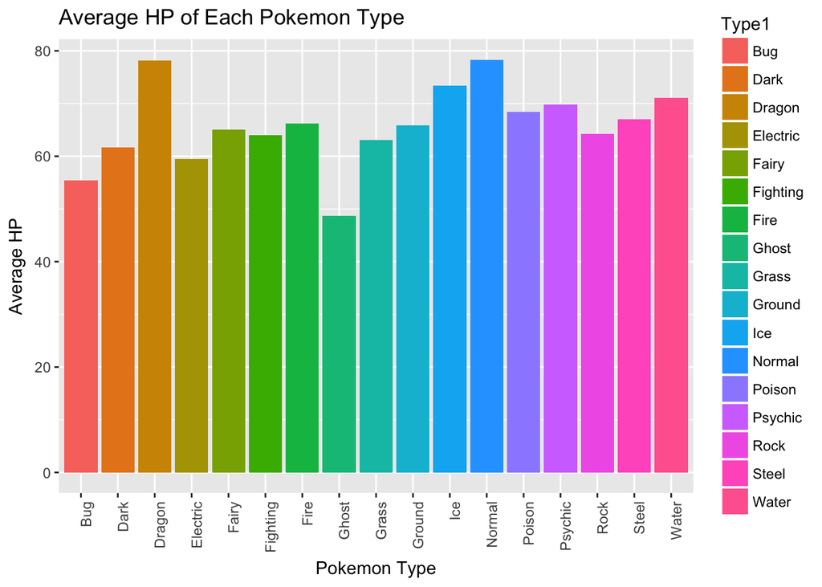

```r
avgStats %>%
  ggplot(mapping=aes(x=Type1, y=avgHP)) + geom_bar(aes(fill=Type1), position="dodge", stat="identity") +  labs(x="Pokemon Type", y="Average HP", title="Average HP of Each Pokemon Type") + theme(axis.text.x=element_text(angle=90, hjust=1))
```

This plot is similar to the one above but instead displays the average attack for each Pokemon type.

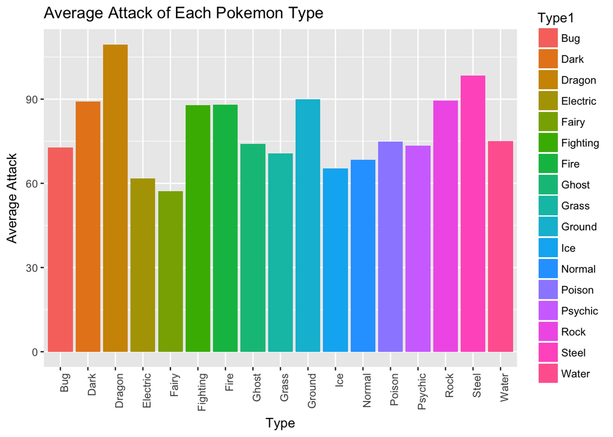

```r
avgStats %>%
  ggplot(mapping=aes(x=Type1, y=avgAttack)) + geom_bar(aes(fill=Type1), position="dodge", stat="identity") +  labs(x="Type", y="Average Attack", title="Average Attack of Each Pokemon Type") + theme(axis.text.x=element_text(angle=90, hjust=1))
```

This plot is similar to the one above but instead displays the average defense for each Pokemon type.

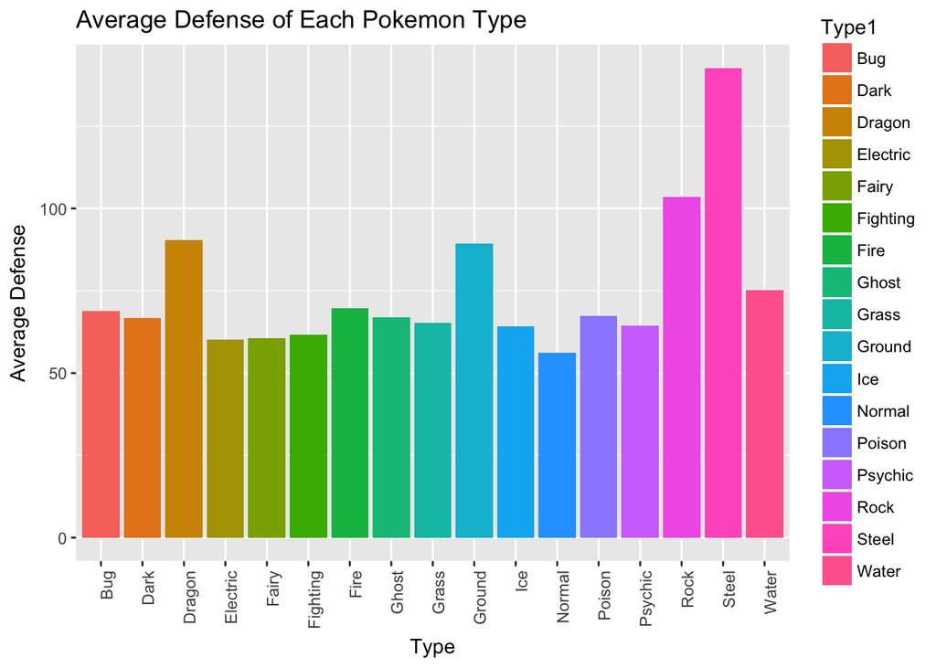

```r
avgStats %>%
  ggplot(mapping=aes(x=Type1, y=avgDefense)) + geom_bar(aes(fill=Type1), position="dodge", stat="identity") +  labs(x="Type", y="Average Defense", title="Average Defense of Each Pokemon Type") + theme(axis.text.x=element_text(angle=90, hjust=1))
```

This plot is similar to the one above but instead displays the average special attack for each Pokemon type.

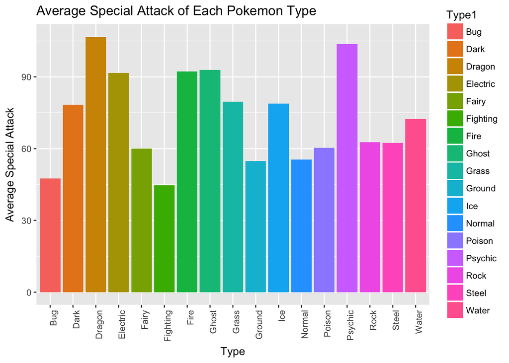

```r
avgStats %>%
  ggplot(mapping=aes(x=Type1, y=avgSpAttack)) + geom_bar(aes(fill=Type1), position="dodge", stat="identity") +  labs(x="Type", y="Average Special Attack", title="Average Special Attack of Each Pokemon Type") + theme(axis.text.x=element_text(angle=90, hjust=1))
```

This plot is similar to the one above but instead displays the average special defense for each Pokemon type.

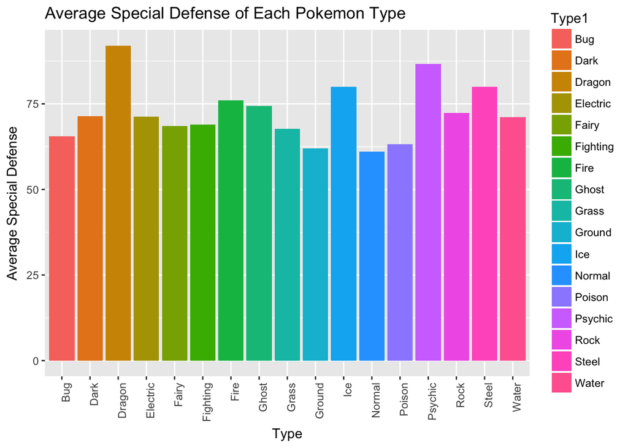

```r
avgStats %>%
  ggplot(mapping=aes(x=Type1, y=avgSpDefense)) + geom_bar(aes(fill=Type1), position="dodge", stat="identity") +  labs(x="Type", y="Average Special Defense", title="Average Special Defense of Each Pokemon Type") + theme(axis.text.x=element_text(angle=90, hjust=1))
```

This plot is similar to the one above but instead displays the average speed for each Pokemon type.

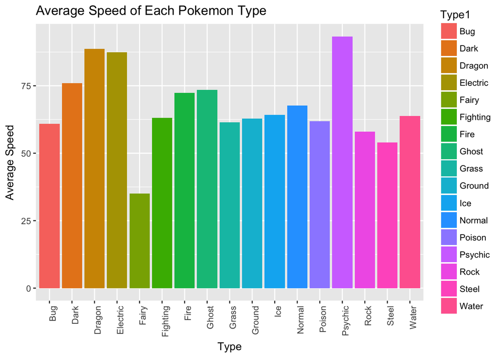

```r
avgStats %>%
  ggplot(mapping=aes(x=Type1, y=avgSpeed)) + geom_bar(aes(fill=Type1), position="dodge", stat="identity") +  labs(x="Type", y="Average Speed", title="Average Speed of Each Pokemon Type") + theme(axis.text.x=element_text(angle=90, hjust=1))
```

Now that we’ve seen several bar graphs, let’s take a look at scatter plots. Scatter plots are useful in seeing the relationship between two variables. Let’s see if there’s a relationship between average attack and average defense for each Pokemon type. Here we have a scatter plot with average attack on the x-axis and average defense on the y-axis. We can see that most types have about the same level for attack as they do for defense. Scatterplots also allow us to see if there are any outliers. From the plot, we can see that the steel and dragon types are far away from the main cluster. The steel type has a much better defense than the other types while the dragon type has a much better attack.

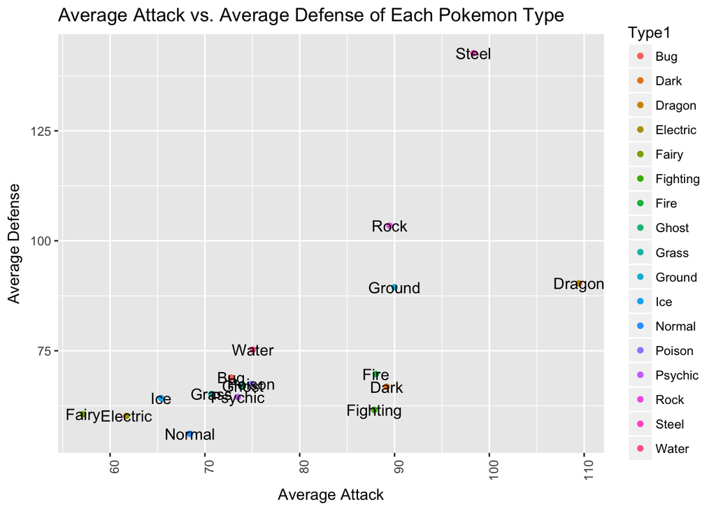

```r
avgStats %>%
  ggplot(mapping=aes(x=avgAttack, y=avgDefense)) + geom_point(aes(color=Type1)) + geom_text(aes(label=Type1)) + labs(x="Average Attack", y="Average Defense", title="Average Attack vs. Average Defense of Each Pokemon Type") + theme(axis.text.x=element_text(angle=90, hjust=1))
```

Now let’s make a similar scatter plot but with average special attack and average special defense. The two outliers in this plot are the dragon and psychic types, with a higher special attack and special defense than the other types.

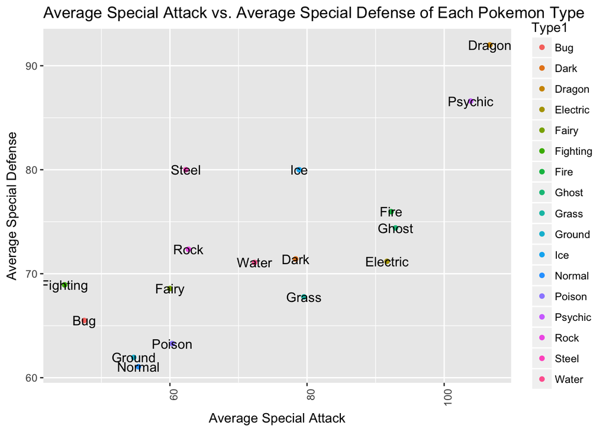

```r
avgStats %>%
  ggplot(mapping=aes(x=avgSpAttack, y=avgSpDefense)) + geom_point(aes(color=Type1)) + geom_text(aes(label=Type1)) +
  labs(x="Average Special Attack", y="Average Special Defense", title="Average Special Attack vs. Average Special Defense of Each Pokemon Type") + theme(axis.text.x=element_text(angle=90, hjust=1))
```

The following three graphs show the average statistics for water Pokemon in each of the three generations.

[figure not shown]

```r
gen1Water <- gen1 %>%
  filter(Type1 == "Water") %>%
  ggplot(mapping=aes(x=Name, y=AverageStats)) + geom_bar(position="dodge", stat="identity") +
  labs(x="Pokemon Name", y="Average Stats", title="Average Stats of Each Water Pokemon in Gen 1") +
  theme(axis.text.x=element_text(angle=90, hjust=1))
gen1Water
```

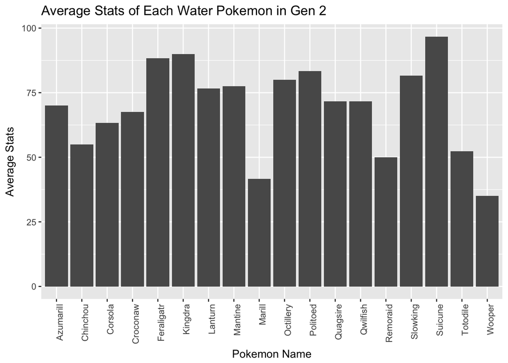

```r
gen2Water <- gen2 %>%
  filter(Type1 == "Water") %>%
  ggplot(mapping=aes(x=Name, y=AverageStats)) + geom_bar(position="dodge", stat="identity") +
  labs(x="Pokemon Name", y="Average Stats", title="Average Stats of Each Water Pokemon in Gen 2") +
  theme(axis.text.x=element_text(angle=90, hjust=1))
gen2Water
```

[figure not shown]

```r
gen3Water <- gen3 %>%
  filter(Type1 == "Water") %>%
  ggplot(mapping=aes(x=Name, y=AverageStats)) + geom_bar(position="dodge", stat="identity") +
  labs(x="Pokemon Name", y="Average Stats", title="Average Stats of Each Water Pokemon in Gen 3") +
  theme(axis.text.x=element_text(angle=90, hjust=1))
gen3Water
```

The following three graphs show the average statistics for fire Pokemon in each of the three generations.

[figure not shown]

```r
gen1Fire <- gen1 %>%
  filter(Type1 == "Fire") %>%
  ggplot(mapping=aes(x=Name, y=AverageStats)) + geom_bar(position="dodge", stat="identity") +
  labs(x="Pokemon Name", y="Average Stats", title="Average Stats of Each Fire Pokemon in Gen 1") +
  theme(axis.text.x=element_text(angle=90, hjust=1))
gen1Fire
```

[figure not shown]

```r
gen2Fire <- gen2 %>%
  filter(Type1 == "Fire") %>%
  ggplot(mapping=aes(x=Name, y=AverageStats)) + geom_bar(position="dodge", stat="identity") +
  labs(x="Pokemon Name", y="Average Stats", title="Average Stats of Each Fire Pokemon in Gen 2") +
  theme(axis.text.x=element_text(angle=90, hjust=1))
gen2Fire
```

[figure not shown]

```r
gen3Fire <- gen3 %>%
  filter(Type1 == "Fire") %>%
  ggplot(mapping=aes(x=Name, y=AverageStats)) + geom_bar(position="dodge", stat="identity") +
  labs(x="Pokemon Name", y="Average Stats", title="Average Stats of Each Fire Pokemon in Gen 3") +
  theme(axis.text.x=element_text(angle=90, hjust=1))
gen3Fire
```

The following three graphs show the average statistics for grass Pokemon in each of the three generations.

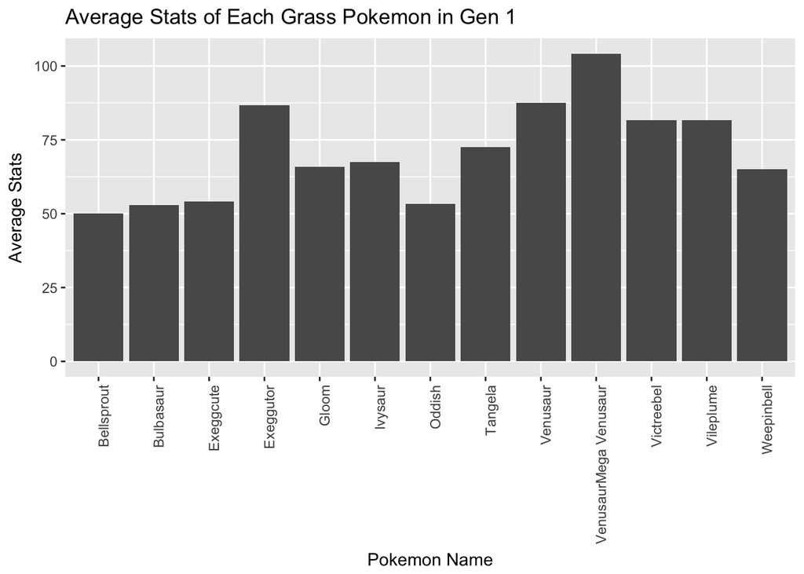

```r
gen1Grass <- gen1 %>%
  filter(Type1 == "Grass") %>%
  ggplot(mapping=aes(x=Name, y=AverageStats)) + geom_bar(position="dodge", stat="identity") +
  labs(x="Pokemon Name", y="Average Stats", title="Average Stats of Each Grass Pokemon in Gen 1") +
  theme(axis.text.x=element_text(angle=90, hjust=1))
gen1Grass
```

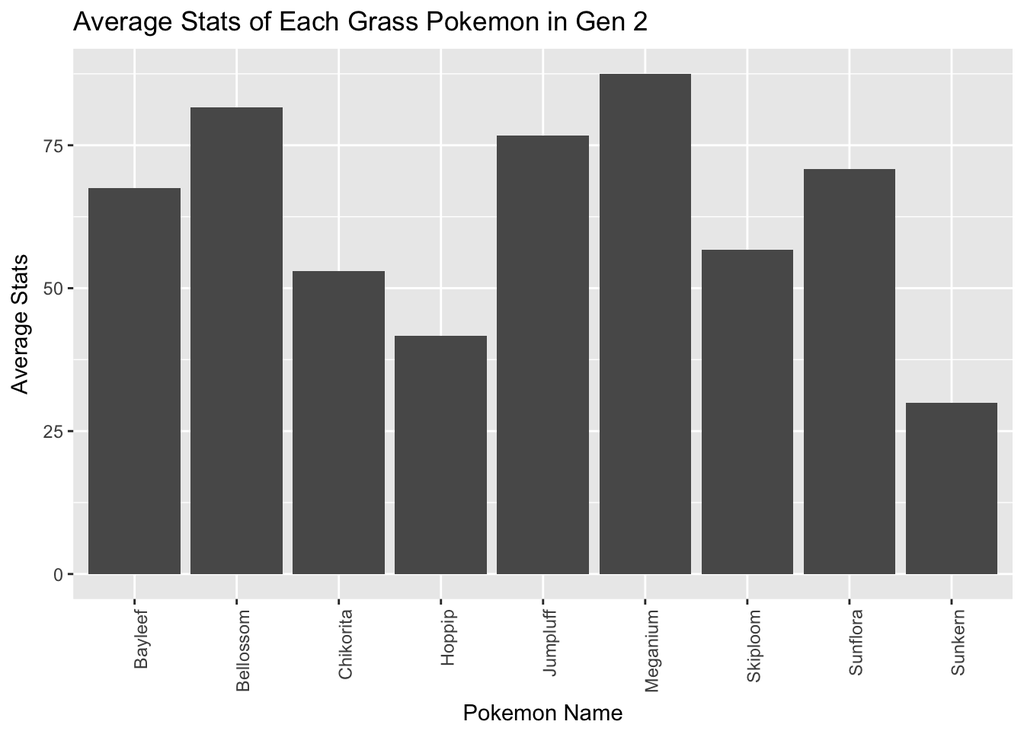

```r
gen2Grass <- gen2 %>%
  filter(Type1 == "Grass") %>%
  ggplot(mapping=aes(x=Name, y=AverageStats)) + geom_bar(position="dodge", stat="identity") +
  labs(x="Pokemon Name", y="Average Stats", title="Average Stats of Each Grass Pokemon in Gen 2") +
  theme(axis.text.x=element_text(angle=90, hjust=1))
gen2Grass
```

[figure not shown]

```r
gen3Grass <- gen3 %>%
  filter(Type1 == "Grass") %>%
  ggplot(mapping=aes(x=Name, y=AverageStats)) + geom_bar(position="dodge", stat="identity") +
  labs(x="Pokemon Name", y="Average Stats", title="Average Stats of Each Grass Pokemon in Gen 3") +
  theme(axis.text.x=element_text(angle=90, hjust=1))
gen3Grass
```

The following three graphs show the average statistics for electric Pokemon in each of the three generations.

[figure not shown]

```r
gen1Electric <- gen1 %>%
  filter(Type1 == "Electric") %>%
  ggplot(mapping=aes(x=Name, y=AverageStats)) + geom_bar(position="dodge", stat="identity") +
  labs(x="Pokemon Name", y="Average Stats", title="Average Stats of Each Electric Pokemon in Gen 1") +
  theme(axis.text.x=element_text(angle=90, hjust=1))
gen1Electric
```

[figure not shown]

```r
gen2Electric <- gen2 %>%
  filter(Type1 == "Electric") %>%
  ggplot(mapping=aes(x=Name, y=AverageStats)) + geom_bar(position="dodge", stat="identity") +
  labs(x="Pokemon Name", y="Average Stats", title="Average Stats of Each Electric Pokemon in Gen 2") +
  theme(axis.text.x=element_text(angle=90, hjust=1))
gen2Electric
```

[figure not shown]

```r
gen3Electric <- gen3 %>%
  filter(Type1 == "Electric") %>%
  ggplot(mapping=aes(x=Name, y=AverageStats)) + geom_bar(position="dodge", stat="identity") +
  labs(x="Pokemon Name", y="Average Stats", title="Average Stats of Each Electric Pokemon in Gen 3") +
  theme(axis.text.x=element_text(angle=90, hjust=1))
gen3Electric
```

Overall, the best water Pokemon are in generation 3. The best fire Pokemon are in generation 1. The best grass Pokemon are also in generation 1. Lastly, the best electric Pokemon are in generation 1.

```r
pokemon %>%
  group_by(Generation, Type1) %>%
  summarize(avg = mean(AverageStats)) %>%
  arrange(Generation)
```

```
## # A tibble: 47 x 3
## # Groups:   Generation [3]
##    Generation Type1      avg
##         <int> <fct>    <dbl>
##  1          1 Bug       61.1
##  2          1 Dragon    73.3
##  3          1 Electric  74.1
##  4          1 Fairy     67.2
##  5          1 Fighting  68.7
##  6          1 Fire      80.2
##  7          1 Ghost     75.6
##  8          1 Grass     71.0
##  9          1 Ground    62.4
## 10          1 Ice       86.2
## # ... with 37 more rows
```

This creates a table that is ordered by the Total attribute in descending order to show the Pokemon with the highest total statistic across all six statistics. We can see that Mewtwo X, Mewtwo Y (Mewtwo has two different forms), and Rayquaza all have the highest total statistic. This means that they are the strongest Pokemon overall across all of the statistics. Kyogre and Groudon come up at a close second, with only 10 points less than Mewtwo X, Mewtwo Y, and Rayquaza. It’s also important to note that most of the Pokemon that have the top total statistics are legendary Pokemon. This shows that legendary Pokemon are the strongest and most powerful compared to the other Pokemon.

```r
highestOverall <- pokemon %>%
  arrange(desc(Total))
head(highestOverall)
```

```
##    ID                    Name   Type1    Type2 Total  HP Attack Defense
## 1 150     MewtwoMega Mewtwo X Psychic Fighting   780 106    190     100
## 2 150     MewtwoMega Mewtwo Y Psychic            780 106    150      70
## 3 384   RayquazaMega Rayquaza  Dragon   Flying   780 105    180     100
## 4 382     KyogrePrimal Kyogre   Water            770 100    150      90
## 5 383   GroudonPrimal Groudon  Ground     Fire   770 100    180     160
## 6 248 TyranitarMega Tyranitar    Rock     Dark   700 100    164     150
##   SpecialAttack SpecialDefense Speed Generation Legendary AverageStats
## 1           154            100   130          1      True     130.0000
## 2           194            120   140          1      True     130.0000
## 3           180            100   115          3      True     130.0000
## 4           180            160    90          3      True     128.3333
## 5           150             90    90          3      True     128.3333
## 6            95            120    71          2     False     116.6667
##   DoubleType
## 1       TRUE
## 2      FALSE
## 3       TRUE
## 4      FALSE
## 5       TRUE
## 6       TRUE
```

This creates a table that displays the maximum total statistic value for each Pokemon type. We can see that the dragon and psychic types have the highest total statistic values, while the fairy type has the lowest. This means that the dragon and psychic types have the strongest Pokemon and the fairy type has the weakest.

```r
overallByType <- pokemon %>%
  group_by(Type1) %>%
  summarize(Top = max(Total)) %>%
  arrange(desc(Top))
overallByType
```

```
## # A tibble: 17 x 2
##    Type1      Top
##    <fct>    <dbl>
##  1 Dragon     780
##  2 Psychic    780
##  3 Ground     770
##  4 Water      770
##  5 Rock       700
##  6 Steel      700
##  7 Fire       680
##  8 Normal     670
##  9 Grass      630
## 10 Electric   610
## 11 Bug        600
## 12 Dark       600
## 13 Ghost      600
## 14 Ice        580
## 15 Poison     535
## 16 Fighting   510
## 17 Fairy      483
```

```r
typeGen1 <- gen1 %>%
  group_by(DoubleType) %>%
  summarize(Number = n()) %>%
  mutate(Generation = "Gen1")
typeGen1
```

```
## # A tibble: 2 x 3
##   DoubleType Number Generation
##   <lgl>       <int> <chr>
## 1 F              88 Gen1
## 2 T              78 Gen1
```

```r
typeGen2 <- gen2 %>%
  group_by(DoubleType) %>%
  summarize(Number = n()) %>%
  mutate(Generation = "Gen2")
typeGen2
```

```
## # A tibble: 2 x 3
##   DoubleType Number Generation
##   <lgl>       <int> <chr>
## 1 F              51 Gen2
## 2 T              55 Gen2
```

```r
typeGen3 <- gen3 %>%
  group_by(DoubleType) %>%
  summarize(Number = n()) %>%
  mutate(Generation = "Gen3")
typeGen3
```

```
## # A tibble: 2 x 3
##   DoubleType Number Generation
##   <lgl>       <int> <chr>
## 1 F              78 Gen3
## 2 T              82 Gen3
```

We can combine together the three tables we just created into one so that our data is more concise.

```r
types <- rbind(typeGen1, typeGen2, typeGen3)
types
```

```
## # A tibble: 6 x 3
##   DoubleType Number Generation
##   <lgl>       <int> <chr>
## 1 F              88 Gen1
## 2 T              78 Gen1
## 3 F              51 Gen2
## 4 T              55 Gen2
## 5 F              78 Gen3
## 6 T              82 Gen3
```

This creates a scatter plot that displays the attack versus special attack for all of the legendary Pokemon in the first three generations. There is correlation between the two variables. The Pokemon with low attack values also tend to have low special attack values and Pokemon with high attack values tend to have high special attack values.

[figure not shown]

```r
legendary %>%
  ggplot(mapping=aes(x=Attack, y=SpecialAttack)) + geom_point(aes(color=Name)) +
  labs(x="Attack", y="Special Attack", title="Attack vs. Special Attack for Legendary Pokemon")
```

Let’s see if the same correlation exists for defense versus special defense in legendary Pokemon. The correlation is about the same with the exception of two outliers. Regirock has a high 200 level defense but has half as much for its special defense. Regice, on the other hand, has a low 100 level defense but has twice as much for its special defense.

[figure not shown]

```r
legendary %>%
  ggplot(mapping=aes(x=Defense, y=SpecialDefense)) + geom_point(aes(color=Name)) +
  labs(x="Defense", y="Special Defense", title="Defense vs. Special Defense for Legendary Pokemon")
```

### Conclusion

The main results we found were:

- The dragon and psychic types are the strongest Pokemon type compared to the rest.
- The dragon type has the best average attack.
- The steel type has the best average defense.
- The dragon type has the best average special attack and special defense.
- The dragon and normal types have the highest HP.
- The psychic type has the best speed.
- The strongest Pokemon are Mewtwo X, Mewtwo Y, and Rayquaza.
- Most of the strongest Pokemon are legendary Pokemon.

From the results, we can see that the dragon type appears a lot, which confirms our findings that the dragon type is indeed the strongest and most powerful Pokemon type of all. The psychic type is also powerful, but doesn’t have as many best statistics as the dragon type. The strongest Pokemon are also legendary Pokemon, which makes sense because these are the Pokemon that you must defeat at the end in order to beat the whole game. Additionally, the strongest Pokemon are Mewtwo X, Mewtwo Y, and Rayquaza, which are psychic and dragon types and are also legendary.